# Behaviour data, Beam Walk

Bindoff, A., Sellas, A.

13 September 2018

Behaviour data were supplied as an Excel file with a sheet for each experiment. AB added two columns titled `exclude` and `comments`. The `comments` column had comments left by AS that were informative, and the `exclude` column was empty except for rows where the comments recommended to exclude the data. These rows were given a 1 so that they were easy to filter out.

We begin by loading some packages that we will use. Packages are software libraries that R users have contributed so that others can use them. For example, the ggplot2 library has a range of useful plotting functions so that we can explore the data and produce publication-ready figures.

To install a new library for the first time or to update a library, run  
install.packages(“package_name”)

e.g install.packages(“ggplot2”)

```r
library(ggplot2)  # for plotting
library(ggbeeswarm) # make beeswarm plots
library(reshape2) # to convert wide format data to long form (or vice versa)
library(dplyr)    # for transforming and summarising data more easily
library(openxlsx) # for reading in sheets from Excel files
library(lme4)     # for mixed effects models
library(lmerTest) # F-tests for mixed effects models fitted with lme4
```

Now we will load the beam walk data using `openxlsx`. `head()` gives us the first 6 lines so we can quickly check that column names are all there and the data has been read in correctly.

```r
bw <- read.xlsx("NFLKO_Motor data_Results_2018.xlsx", sheet = 1)
bw$genotype <- factor(bw$genotype, levels = c("control", "tg"))
bw$month <- factor(bw$month)
head(bw)
```

```
##     id genotype month t1_slip t1_synch t1_time t2_slip t2_synch t2_time
## 1 6464  control     1       0        1    8.81       0        0    9.85
## 2 6469  control     1       0        1    4.36       1        0    4.76
## 3 6470  control     1       2        0    6.27       2        0    4.89
## 4 6471  control     1       2        1    5.41       3        1    4.34
## 5 6472  control     1       2        1    8.49       2        0    9.40
## 6 6473  control     1       1        0    4.59       0        0    3.92
##   t3_slip t3_synch t3_time exclude                      comments
## 1       1        2   17.29       1 Exclude due to single housing
## 2       0        0    4.42      NA                          <NA>
## 3       0        4    4.85      NA                          <NA>
## 4       2        6    5.51      NA                          <NA>
## 5       2        0   11.49      NA                          <NA>
## 6       1        0    4.77      NA                          <NA>
```

We can use the `dplyr` function `filter` to filter out rows with a 1 in the `exclude` column. I am in the habit of typing out the package name and function because lots of packages have `filter` functions and I want to make sure that R knows to call this function from the `dplyr` library (not the ‘::’ between package name and function name)

```r
cat("\nrows before filter = ", nrow(bw))  # check number of rows before we filter
bw <- dplyr::filter(bw, is.na(exclude))   # "filter all rows from bw where exclude = NA"
cat("\nrows after filter = ", nrow(bw))   # check number of rows after we filter
```

```
##
## rows before filter =  109
## rows after filter =  105
```

You can view all of your beam walk data in the RStudio data viewer by running  
View(bw)

Because we will be using a repeated measures analysis, we want our data to be in “long” form, with each trial per animal on a different row, and each measure in a different table.

```r
slip <- select(bw, id, genotype, month, ends_with("slip")) %>%
  melt(id.vars = c("id", "genotype", "month"), na.rm = FALSE)
synch <- select(bw, id, genotype, month, ends_with("synch")) %>%
    melt(id.vars = c("id", "genotype", "month"), na.rm = FALSE)
timed <- select(bw, id, genotype, month, ends_with("time")) %>%
    melt(id.vars = c("id", "genotype", "month"), na.rm = FALSE)

head(timed)
```

```
##     id genotype month variable value
## 1 6469  control     1  t1_time  4.36
## 2 6470  control     1  t1_time  6.27
## 3 6471  control     1  t1_time  5.41
## 4 6472  control     1  t1_time  8.49
## 5 6473  control     1  t1_time  4.59
## 6 6480  control     1  t1_time  5.37
```

We now have two new columns, `variable` which tells us which trial the row is for and `value` which tells us the time taken (in this case).

We can plot the data to get a sense of what’s happening, and also to check for any problems. Let’s start with slips-

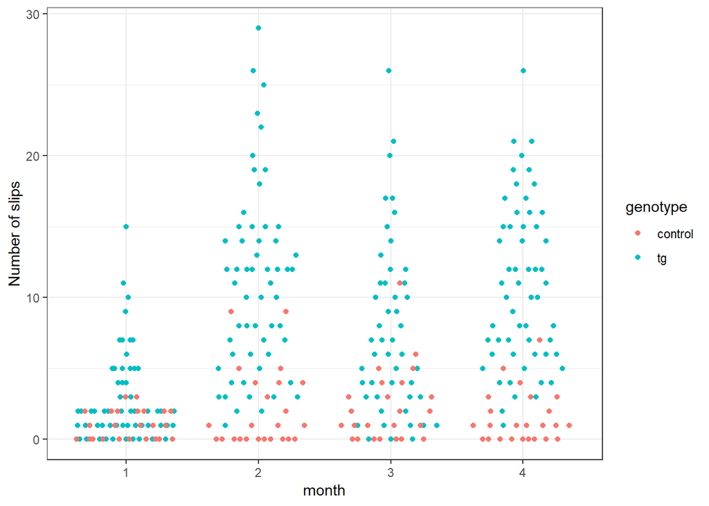

```r
ggplot(slip, aes(x = month, y = value, colour = genotype)) +
  geom_quasirandom() +
  ylab("Number of slips") +
  theme_bw()
```

It’s pretty clear that the data are not normally distributed. In fact they are counts, so this is not surprising at all, as counts are often better described by a Poisson function. It looks like there is an effect of month, but it’s not linearly increasing. Months 2, 3, and 4 are different to month 1 but fairly similar to each other.

Let’s see if the time measure looks any more normally distributed.

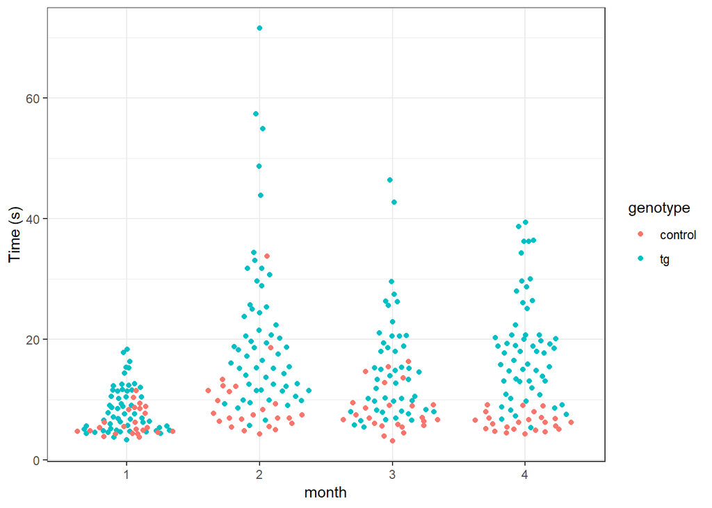

```r
ggplot(timed, aes(x = month, y = value, colour = genotype)) +
  geom_quasirandom() +
    ylab("Time (s)") +
  theme_bw()
```

Unfortunately no, but a log transformation often helps so we’ll try this. I’ve also added some custom colours so that you can make your own figures however you like them.

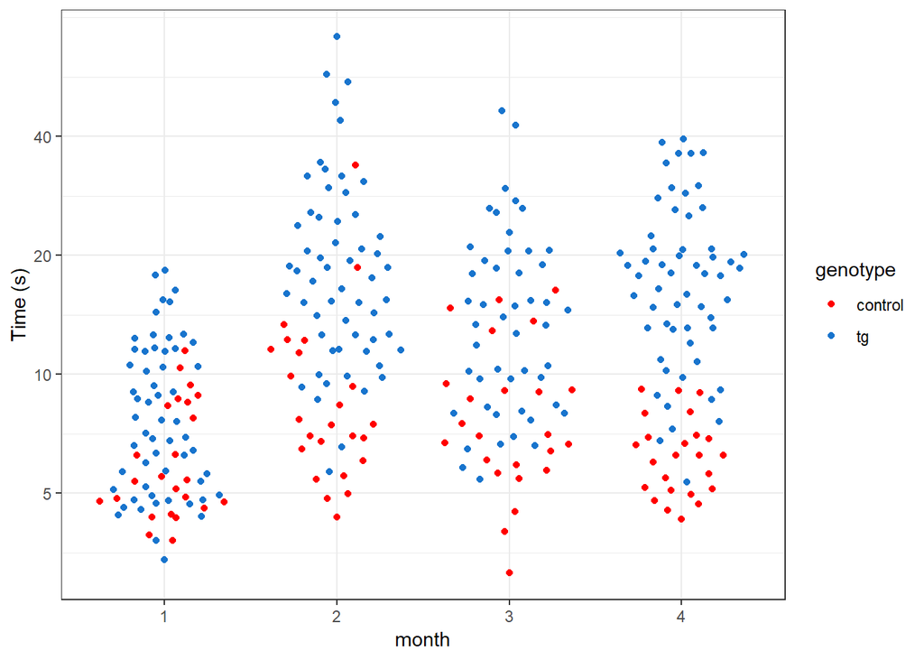

```r
ggplot(timed, aes(x = month, y = value, colour = genotype)) +
  geom_quasirandom() +
  scale_y_continuous(trans = "log", breaks = c(5, 10, 20, 40)) +
  scale_colour_manual(values = c("red", "dodgerblue3")) +
  ylab("Time (s)") +
  theme_bw()
```

Again, a similar pattern to the slips data. Month 1 is different, there is not a linear increase over each month. There might possibly be more of an effect for tg mice than for controls, and it’s possible that we might be seeing a “frowny face” pattern over time.

### Analysis

Let’s start with slips, because this is a tricky one. An assumption of most statistical tests that you learn in undergrad is that the observations are independent. Clearly this is not the case here, for each animal you have 3 observations (t1, t2, t3) at each time point, and 4 time points (month 1, month 2, ..). One way to deal with this is to use repeated measures analysis, but you have two violations of independence - multiple observations at each month. You could average the observations at each month, and this is a good way to solve the problem but it throws away information about how much the observations at each month vary.

The analysis that we’re going to use is called a mixed effects model or multilevel model. This approach treats clustering or dependence in the data as a different “level” of the data. We can relax the assumption of independence by estimating a mean and variance for each animal at each time point. We call this the “random” or “group level” effect.

The treatment (genotype in your experiment) we call the “fixed” or “population level” effect. Because the model includes both fixed and random effects it is sometimes called a mixed effects model.

Let’s start with a model that estimates the effect of genotype on number of slips, estimating a mean (and variance) for each animal at each month.

```r
m1 <- lmer(value ~ genotype + month + (month|id), slip)
round(summary(m1)$coefficients, 3)
```

```
##             Estimate Std. Error     df t value Pr(>|t|)
## (Intercept)    0.111      0.808 31.338   0.137    0.892
## genotypetg     3.210      0.926 28.605   3.468    0.002
## month2         5.988      1.071 26.304   5.592    0.000
## month3         3.891      0.891 23.390   4.365    0.000
## month4         5.667      1.077 26.007   5.260    0.000
```

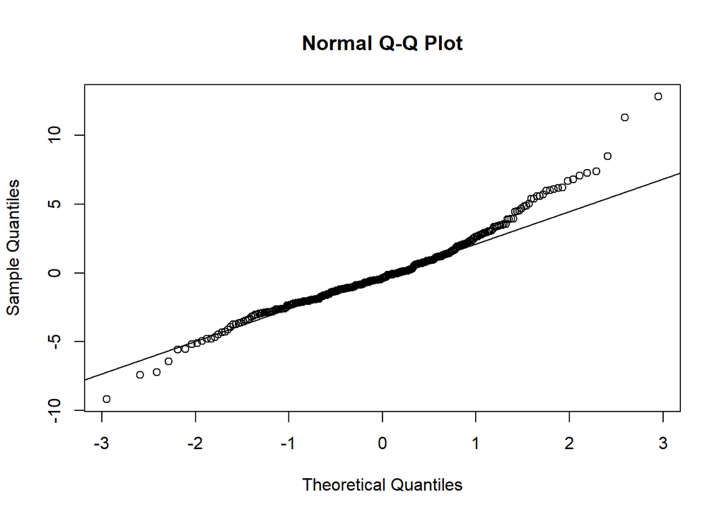

```r
qqnorm(resid(m1))
qqline(resid(m1))
```

These assumptions are obviously quite severely violated, so let’s look a little closer at this problem.

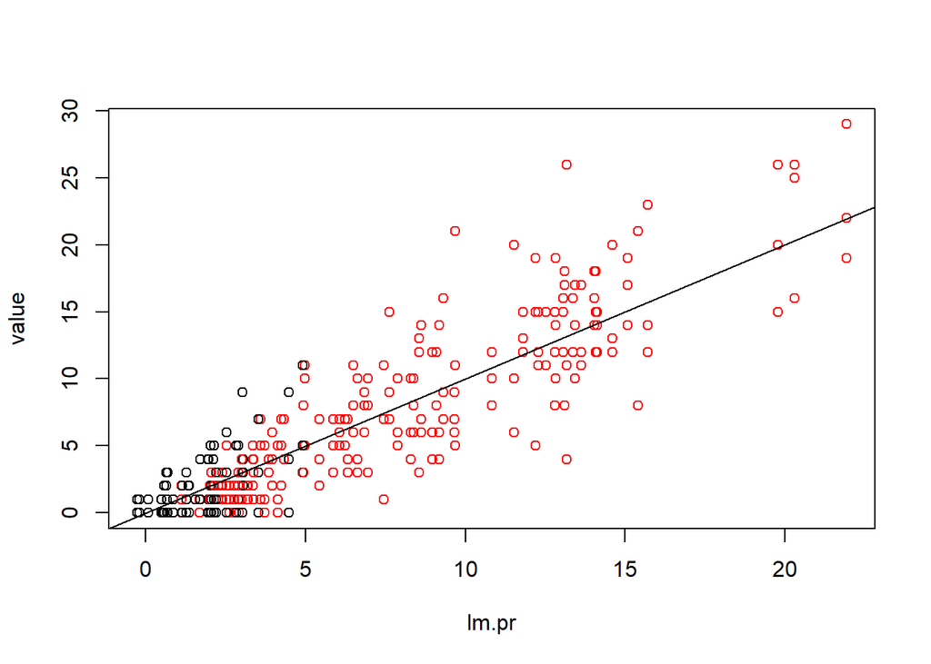

```r
slip$lm.pr <- predict(m1, slip)

plot(value ~ lm.pr, slip, col = genotype)
abline(0, 1)
```

We can also model this data assuming the data are drawn from a Poisson distribution (a very reasonable assumption because counts often are). We can do this with a generalised linear mixed model (GLMM). This is almost the same thing as the linear mixed model except that we use a Poisson “link function” which maps the count distribution back to a normal distribution so that we get good estimates and valid p-values.

```r
m2 <- glmer(value ~ genotype + month + (month|id), slip, family = "poisson")
slip$glmm.pr <- predict(m2, slip, type = "response")
```

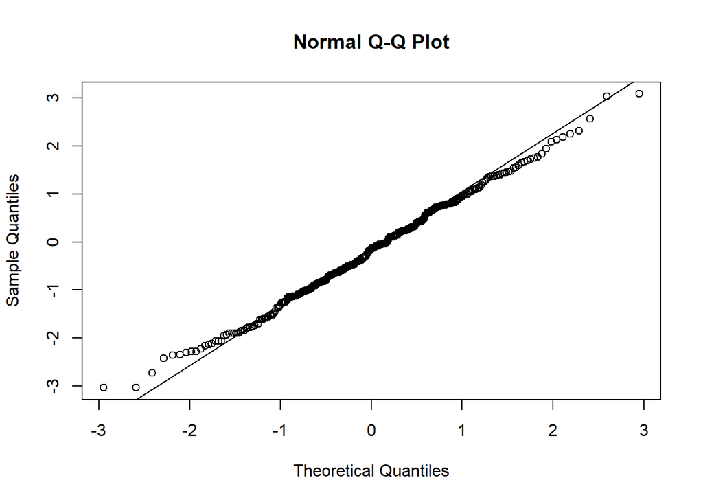

```r
qqnorm(resid(m2))
qqline(resid(m2))
```

Much better! How well does the model predict counts?

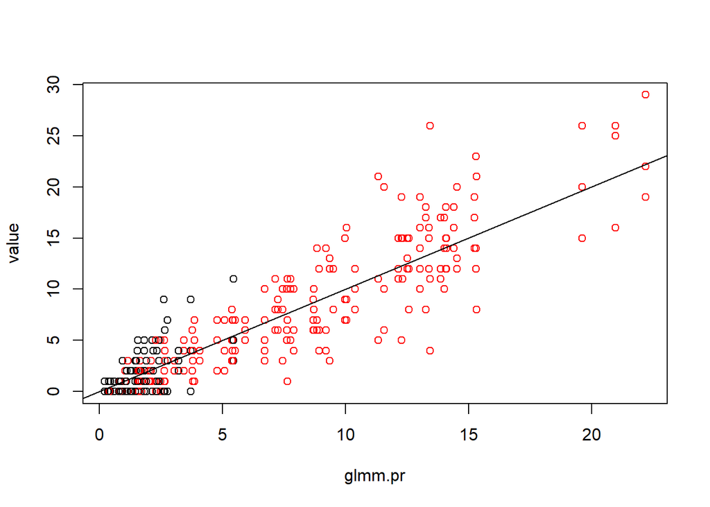

```r
plot(value ~ glmm.pr, slip, col = genotype)
abline(0,1)
```

The model predictions are incredibly close to the linear model (nearly identical). P-values are a bit trickier, we need to compare the model with another model that doesn’t have the term we want the p-value for.

```r
m2_null_geno <- glmer(value ~ month + (month|id), slip, family = "poisson")
m2_null_month <- glmer(value ~ genotype + (month|id), slip, family = "poisson")

anova(m2, m2_null_geno)

anova(m2, m2_null_month)
```

```
## Data: slip
## Models:
## m2_null_geno: value ~ month + (month | id)
## m2: value ~ genotype + month + (month | id)
##              Df    AIC    BIC  logLik deviance Chisq Chi Df Pr(>Chisq)
## m2_null_geno 14 1617.1 1669.6 -794.53   1589.1
## m2           15 1584.8 1641.1 -777.41   1554.8 34.23      1  4.896e-09 ***
## ---
## Signif. codes:  0 '***' 0.001 '**' 0.01 '*' 0.05 '.' 0.1 ' ' 1
## Data: slip
## Models:
## m2_null_month: value ~ genotype + (month | id)
## m2: value ~ genotype + month + (month | id)
##               Df    AIC    BIC  logLik deviance  Chisq Chi Df Pr(>Chisq)
## m2_null_month 12 1612.7 1657.7 -794.34   1588.7
## m2            15 1584.8 1641.1 -777.41   1554.8 33.844      3  2.137e-07
##
## m2_null_month
## m2            ***
## ---
## Signif. codes:  0 '***' 0.001 '**' 0.01 '*' 0.05 '.' 0.1 ' ' 1
```

This is called a “likelihood ratio test”, and we report the Chi-squared statistic with degrees of freedom like so,

“There was a significant effect of genotype $\chi^2_1 = 34.2, p < .001$ and month $\chi^2_3 = 33.8, p < .001$…”

It’s also important to report the strength and direction of the effects, so let’s have a look at the co-efficients for month (averaged over the levels of genotype)

```r
lsmeans::lsmeans(m2, specs = "month", transform = "response")
```

```
##  month     rate        SE df asymp.LCL asymp.UCL
##  1     1.515989 0.2972943 NA 0.9333027  2.098675
##  2     5.847306 0.7021055 NA 4.4712044  7.223407
##  3     4.216185 0.8150308 NA 2.6187539  5.813616
##  4     5.678040 0.5726774 NA 4.5556125  6.800467
##
## Results are averaged over the levels of: genotype
## Confidence level used: 0.95
```

…and for genotype (averaged over the levels of month)

```r
lsmeans::lsmeans(m2, specs = "genotype", transform = "response")
```

```
##  genotype     rate        SE df asymp.LCL asymp.UCL
##  control  1.203109 0.2483400 NA 0.7163718  1.689847
##  tg       7.425650 0.9312842 NA 5.6003667  9.250934
##
## Results are averaged over the levels of: month
## Confidence level used: 0.95
```

The rate is the number of slips per trial, so for example you might write up

“Averaging over all months, control mice slipped 1.2 times per trial (95%CI 0.7, 1.7) while tg mice slipped 7.4 times per trial (95%CI 5.6, 9.3)…”

These results are intrepretable showing both the strength and direction of the effect in the units that they were observed, and reporting a measure of uncertainty in the estimates.

#### Time

Let’s begin by fitting a linear mixed effects model as we did initially for the steps data, but we’ll also fit a model with log-transformed time.

```r
timed$month <- factor(timed$month)
m3.lin <- lmer(value ~ genotype + month + (month|id), timed)
m3.log <- lmer(log(value) ~ genotype + month + (month|id), timed)
```

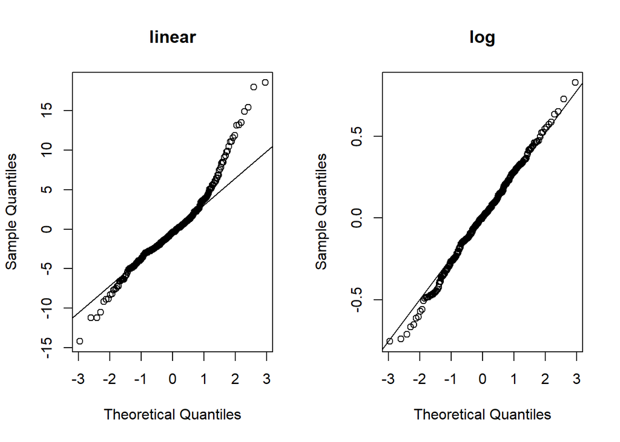

```r
par(mfrow = c(1, 2))
qqnorm(resid(m3.lin), main = "linear")
qqline(resid(m3.lin))

qqnorm(resid(m3.log), main = "log")
qqline(resid(m3.log))
```

Let’s check genotype * month interaction and compare with the main effects model, m3.log

```r
m3.int <- lmer(log(value) ~ genotype*month + (month|id), timed)
anova(m3.int, m3.log)
```

```
## Data: timed
## Models:
## ..1: log(value) ~ genotype + month + (month | id)
## object: log(value) ~ genotype * month + (month | id)
##        Df    AIC    BIC  logLik deviance  Chisq Chi Df Pr(>Chisq)
## ..1    16 335.75 395.80 -151.88   303.75
## object 19 318.05 389.35 -140.03   280.05 23.705      3  2.879e-05 ***
## ---
## Signif. codes:  0 '***' 0.001 '**' 0.01 '*' 0.05 '.' 0.1 ' ' 1
```

The model with the interaction term is significantly better. We don’t need to report the Chisq statistic like we did for the GLMM here, we can calculate an F-statistic for the interaction term, and estimate the strength and direction of effects -

```r
nd <- expand.grid(genotype = factor(c("control", "tg")),
                  month = factor(c(1, 2, 3, 4)))
nd$fit <- round(exp(predict(m3.int, nd, re.form = NA)), 1)
nd
anova(m3.int)
```

```
##   genotype month  fit
## 1  control     1  6.0
## 2       tg     1  7.8
## 3  control     2  8.4
## 4       tg     2 18.0
## 5  control     3  7.6
## 6       tg     3 14.6
## 7  control     4  6.2
## 8       tg     4 16.9
## Analysis of Variance Table of type III  with  Satterthwaite
## approximation for degrees of freedom
##                Sum Sq Mean Sq NumDF  DenDF F.value    Pr(>F)
## genotype       2.5115  2.5115     1 24.037  25.272 3.864e-05 ***
## month          8.9404  2.9801     3 20.252  29.988 1.204e-07 ***
## genotype:month 3.6674  1.2225     3 20.252  12.301 8.385e-05 ***
## ---
## Signif. codes:  0 '***' 0.001 '**' 0.01 '*' 0.05 '.' 0.1 ' ' 1
```

I would report like this -

“There was a significant interaction between genotype and month (F(3, 20.2) = 12.3, p < .001) and significant main effect of month (F(3, 20.2) = 30.0, p < .001) and genotype (F…). After adjusting for the main effects of month (see Table x), tg mice took on average between 7.0 and 10.7 seconds longer (approximately) to cross the beam than control mice in months 2, 3, and 4, and just 1.8 seconds longer at month 1.”